# Practical Machine Learning - Human Activity Recognition

Tianzi Harrison

Friday, May 22, 2015

The goal of this assignment is to choose a prediction model from the caret package in R so that it can correctly tell the manner people carry out weight-lifting exercises, given data collected by wearable devices.

The raw data come from the paper “Qualitative Activity Recognition of Weight Lifting Exercises” presented at SIGCHI 2013. The data include direct readings from sensors on four wearable devices, i.e. the three-axes acceleration, gyroscope, and magnetometer data from belt, glove, arm-band, and dumbell; they also include values calculated for the three Euler angles, i.e., the mean, variance, standard deviation, max, min, amplitude, kurtosis, and skewness for roll, pitch, and yaw.

```r
        require(gbm); require(rpart); require(plyr); require(randomForest)
        require(lubridate); require(dplyr); require(caret); require(rattle)

        fileURL1 <- "https://d396qusza40orc.cloudfront.net/predmachlearn/pml-training.csv"
        fileURL2 <- "https://d396qusza40orc.cloudfront.net/predmachlearn/pml-testing.csv"
        if(!file.exists("pml-training.csv")){
                download.file(fileURL1, destfile = "pml-training.csv", method = "curl")
        }
        if(!file.exists("pml-testing.csv")){
                download.file(fileURL2, destfile = "pml-testing.csv", method = "curl")
        }

        t <- read.csv("pml-training.csv", header = T, na.strings = c("","NA", "#DIV/0!"))
        f <- read.csv("pml-testing.csv", header = T, na.strings = c("", "NA", "#DIV/0!"))

        identical(t$skewness_roll_belt, t$skewness_roll_belt.1)
```

```
## [1] FALSE
```

It is unclear why there are two skewness values for the Euler angle roll from the belt sensor. However, since they are not identical, removing either would be unwarranted.

#### Prepare the training set for cross validation

```r
        t[c(1,10,1000,5000,9000), c(1:6, 160)]
```

```
##         X user_name raw_timestamp_part_1 raw_timestamp_part_2
## 1       1  carlitos           1323084231               788290
## 10     10  carlitos           1323084232               484434
## 1000 1000    adelmo           1322832784               596547
## 5000 5000    adelmo           1322832822               948294
## 9000 9000    eurico           1322489660               650694
##        cvtd_timestamp new_window classe
## 1    05/12/2011 11:23         no      A
## 10   05/12/2011 11:23         no      A
## 1000 02/12/2011 13:33         no      A
## 5000 02/12/2011 13:33         no      A
## 9000 28/11/2011 14:14         no      B
```

Furthermore, it is impossible to know at this stage how to impute missing values for any variable in the dataset. The best way to deal with missing values may be to exclude them when trying to train the data.

```r
        index <- which(colSums(is.na(t)) == 0)[-1:-5]
        train <- t[, index]
        test <- f[, index]
# set numeric class for all variables in the train and test sets, except for classe
        for (i in 1:(length(index)-1)){
                train[, i] <- as.numeric(train[, i])
                test[, i] <- as.numeric(test[, i])
        }
```

Next, I built a 2-fold cross validation manually inside my training data by spliting the data 80/20.

```r
        set.seed(111)
        inTrain <- createDataPartition(y = train$classe, p = 0.8, list = FALSE)
        trainInTrain <- train[inTrain,]
        testInTrain <- train[-inTrain,]
```

#### Select models: rpart, gbm, rf

The first model tried is **rpart**, it is fast to run and easy to interpret. I believe it goes through the data once only and creates one tree.

[figure not shown]

```r
        set.seed(111)
        rpartFit <- train(classe ~ ., method = "rpart", data = trainInTrain)
        if(!file.exists("rpartFit.rds")){
                rpartFit <- train(classe ~ ., method = "rpart", data = trainInTrain)
                saveRDS(rpartFit, "rpartFit.rds")
        } else{
                rpartFit <- readRDS("rpartFit.rds")
        }
        fancyRpartPlot(rpartFit$finalModel)
```

```r
# apply the model to the test in training dataset
        rpartPred <- predict(rpartFit, newdata = testInTrain)
        confusionMatrix(rpartPred, testInTrain$classe)
```

```
## Confusion Matrix and Statistics
##
##           Reference
## Prediction   A   B   C   D   E
##          A 976 182 100 112  21
##          B  13 262  22 115  49
##          C 123 315 562 385 209
##          D   0   0   0   0   0
##          E   4   0   0  31 442
##
## Overall Statistics
##
##                Accuracy : 0.5715
##                  95% CI : (0.5558, 0.5871)
##     No Information Rate : 0.2845
##     P-Value [Acc > NIR] : < 2.2e-16
##
##                   Kappa : 0.4529
##  Mcnemar's Test P-Value : < 2.2e-16
##
## Statistics by Class:
##
##                      Class: A Class: B Class: C Class: D Class: E
## Sensitivity            0.8746  0.34519   0.8216   0.0000   0.6130
## Specificity            0.8522  0.93710   0.6814   1.0000   0.9891
## Pos Pred Value         0.7017  0.56833   0.3526      NaN   0.9266
## Neg Pred Value         0.9447  0.85644   0.9476   0.8361   0.9190
## Prevalence             0.2845  0.19347   0.1744   0.1639   0.1838
## Detection Rate         0.2488  0.06679   0.1433   0.0000   0.1127
## Detection Prevalence   0.3546  0.11751   0.4063   0.0000   0.1216
## Balanced Accuracy      0.8634  0.64115   0.7515   0.5000   0.8011
```

When this model is applied to the testing data in the training set, the accuracy rate, unfortunately, is low, at only 57%. The model is abandoned. A more sophisticated model is needed for the problem.

The second model to try is the **generalized boosting model** or **Stochastic Gradient Boosting**, which is an ensemble of regression and classification trees. All parameters are taken as their default values.

```r
        set.seed(111)
        if(!file.exists("gbmFit.rds")){
                gbmFit <- train(classe ~ ., data = trainInTrain, method = "gbm",
                                verbose = F)
                saveRDS(gbmFit, "gbmFit.rds")
        }else{
                gbmFit <- readRDS("gbmFit.rds")
        }
        gbmFit
```

```
## Stochastic Gradient Boosting
##
## 15699 samples
##    54 predictor
##     5 classes: 'A', 'B', 'C', 'D', 'E'
##
## No pre-processing
## Resampling: Bootstrapped (25 reps)
##
## Summary of sample sizes: 15699, 15699, 15699, 15699, 15699, 15699, ...
##
## Resampling results across tuning parameters:
##
##   interaction.depth  n.trees  Accuracy   Kappa      Accuracy SD
##   1                   50      0.7569624  0.6916445  0.009215614
##   1                  100      0.8269978  0.7809785  0.007530145
##   1                  150      0.8680871  0.8330513  0.006622483
##   2                   50      0.8851515  0.8546027  0.006662410
##   2                  100      0.9382463  0.9218630  0.004656608
##   2                  150      0.9616855  0.9515278  0.003533833
##   3                   50      0.9310669  0.9127478  0.006356771
##   3                  100      0.9693984  0.9612870  0.002848360
##   3                  150      0.9841540  0.9799577  0.002038803
##   Kappa SD
##   0.011729938
##   0.009489075
##   0.008357662
##   0.008466308
##   0.005902415
##   0.004468671
##   0.008038270
##   0.003601100
##   0.002575005
##
## Tuning parameter 'shrinkage' was held constant at a value of 0.1
##
## Tuning parameter 'n.minobsinnode' was held constant at a value of 10
## Accuracy was used to select the optimal model using  the largest value.
## The final values used for the model were n.trees = 150,
##  interaction.depth = 3, shrinkage = 0.1 and n.minobsinnode = 10.
```

gbmFit contains 54 predictors (with varying relative influence, some zero) with 25 bootstrapped samples of the same size as the train in train dataset. 54 is much greater than 17 in the published paper. However, there are exactly 18 with a relative influence of greater than 1, excluding num_window. The accuracy of the model improves to 98.4%.

```r
        summary(gbmFit)
```

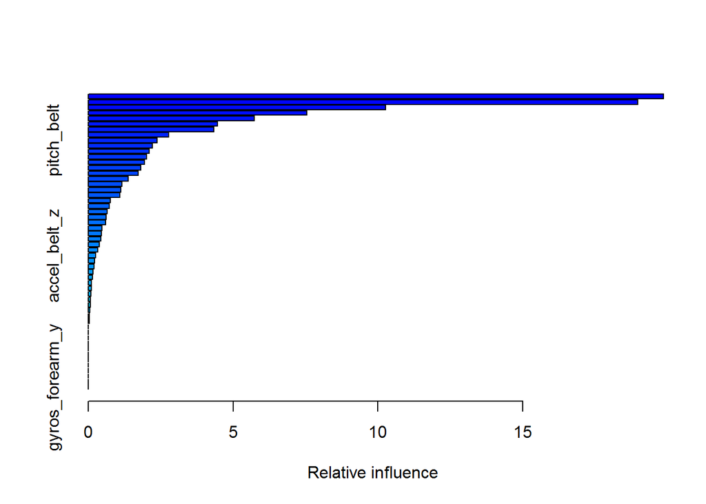

```
##                                       var     rel.inf
## num_window                     num_window 19.86320408
## roll_belt                       roll_belt 18.97822151
## pitch_forearm               pitch_forearm 10.26049229
## magnet_dumbbell_z       magnet_dumbbell_z  7.54226957
## yaw_belt                         yaw_belt  5.73888299
## roll_forearm                 roll_forearm  4.47298780
## magnet_dumbbell_y       magnet_dumbbell_y  4.34570059
## magnet_belt_z               magnet_belt_z  2.78197908
## pitch_belt                     pitch_belt  2.38443808
## accel_forearm_x           accel_forearm_x  2.22040754
## roll_dumbbell               roll_dumbbell  2.09951509
## accel_dumbbell_y         accel_dumbbell_y  2.01054411
## gyros_dumbbell_y         gyros_dumbbell_y  1.94206160
## accel_dumbbell_z         accel_dumbbell_z  1.81010861
## gyros_belt_z                 gyros_belt_z  1.72393720
## accel_dumbbell_x         accel_dumbbell_x  1.38504495
## accel_forearm_z           accel_forearm_z  1.16879498
## yaw_arm                           yaw_arm  1.13430519
## magnet_forearm_z         magnet_forearm_z  1.09674921
## magnet_belt_x               magnet_belt_x  0.76646552
## magnet_belt_y               magnet_belt_y  0.73450341
## magnet_arm_z                 magnet_arm_z  0.65266030
## roll_arm                         roll_arm  0.61549084
## gyros_arm_y                   gyros_arm_y  0.60204004
## magnet_dumbbell_x       magnet_dumbbell_x  0.47094707
## magnet_arm_x                 magnet_arm_x  0.44849685
## magnet_forearm_x         magnet_forearm_x  0.43118778
## gyros_belt_y                 gyros_belt_y  0.37918113
## accel_arm_x                   accel_arm_x  0.31986546
## accel_belt_z                 accel_belt_z  0.26006930
## total_accel_dumbbell total_accel_dumbbell  0.21322917
## accel_forearm_y           accel_forearm_y  0.19324774
## magnet_arm_y                 magnet_arm_y  0.17285817
## gyros_dumbbell_x         gyros_dumbbell_x  0.15092107
## gyros_forearm_z           gyros_forearm_z  0.11266627
## total_accel_arm           total_accel_arm  0.10969982
## total_accel_forearm   total_accel_forearm  0.10050769
## pitch_dumbbell             pitch_dumbbell  0.08050762
## gyros_dumbbell_z         gyros_dumbbell_z  0.07951640
## magnet_forearm_y         magnet_forearm_y  0.06416397
## gyros_arm_x                   gyros_arm_x  0.04465969
## yaw_forearm                   yaw_forearm  0.03747022
## new_window                     new_window  0.00000000
## total_accel_belt         total_accel_belt  0.00000000
## gyros_belt_x                 gyros_belt_x  0.00000000
## accel_belt_x                 accel_belt_x  0.00000000
## accel_belt_y                 accel_belt_y  0.00000000
## pitch_arm                       pitch_arm  0.00000000
## gyros_arm_z                   gyros_arm_z  0.00000000
## accel_arm_y                   accel_arm_y  0.00000000
## accel_arm_z                   accel_arm_z  0.00000000
## yaw_dumbbell                 yaw_dumbbell  0.00000000
## gyros_forearm_x           gyros_forearm_x  0.00000000
## gyros_forearm_y           gyros_forearm_y  0.00000000
```

```r
# apply model
        gbmPred <- predict(gbmFit, newdata = testInTrain)
        confusionMatrix(gbmPred, testInTrain$classe)
```

```
## Confusion Matrix and Statistics
##
##           Reference
## Prediction    A    B    C    D    E
##          A 1111    5    0    0    0
##          B    4  740    9    8    4
##          C    0   12  672    6    1
##          D    1    2    3  628    8
##          E    0    0    0    1  708
##
## Overall Statistics
##
##                Accuracy : 0.9837
##                  95% CI : (0.9792, 0.9874)
##     No Information Rate : 0.2845
##     P-Value [Acc > NIR] : < 2.2e-16
##
##                   Kappa : 0.9794
##  Mcnemar's Test P-Value : NA
##
## Statistics by Class:
##
##                      Class: A Class: B Class: C Class: D Class: E
## Sensitivity            0.9955   0.9750   0.9825   0.9767   0.9820
## Specificity            0.9982   0.9921   0.9941   0.9957   0.9997
## Pos Pred Value         0.9955   0.9673   0.9725   0.9782   0.9986
## Neg Pred Value         0.9982   0.9940   0.9963   0.9954   0.9960
## Prevalence             0.2845   0.1935   0.1744   0.1639   0.1838
## Detection Rate         0.2832   0.1886   0.1713   0.1601   0.1805
## Detection Prevalence   0.2845   0.1950   0.1761   0.1637   0.1807
## Balanced Accuracy      0.9969   0.9835   0.9883   0.9862   0.9908
```

The accuracy rate of the gbm model is also 98.4% when applied to the validation dataset in the training set. The expected out-of-sample error rate is one minus that value, which is 1.6%.

The third model to try is **random forest**. Technically, this model shall be applied to the entire training set instead of a subset of the training set because the out-of-bag error rate is a good estimate of the out-of-sample error rate.

```r
        set.seed(111)
        if(!file.exists("rfFit.rds")){
                rfFit <- randomForest(classe ~ ., data = trainInTrain, prox = T)
                saveRDS(rfFit, "rfFit.rds")
        }else{
                rfFit <- readRDS("rfFit.rds")
        }
        rfFit
```

```
##
## Call:
##  randomForest(formula = classe ~ ., data = trainInTrain, prox = T)
##                Type of random forest: classification
##                      Number of trees: 500
## No. of variables tried at each split: 7
##
##         OOB estimate of  error rate: 0.16%
## Confusion matrix:
##      A    B    C    D    E class.error
## A 4464    0    0    0    0 0.000000000
## B    3 3034    1    0    0 0.001316656
## C    0    5 2733    0    0 0.001826150
## D    0    0   10 2561    2 0.004663817
## E    0    0    0    4 2882 0.001386001
```

As 500 trees are created, the out-of-bag estimate of error rate is 0.16%. I expect the out-of-sample error to be close to the out-of-bag error rate for the random forest model on the train in train dataset.

```r
        rfPred <- predict(rfFit, newdata = testInTrain)
        confusionMatrix(rfPred, testInTrain$classe)
```

```
## Confusion Matrix and Statistics
##
##           Reference
## Prediction    A    B    C    D    E
##          A 1116    2    0    0    0
##          B    0  756    2    0    0
##          C    0    1  682    3    0
##          D    0    0    0  640    0
##          E    0    0    0    0  721
##
## Overall Statistics
##
##                Accuracy : 0.998
##                  95% CI : (0.996, 0.9991)
##     No Information Rate : 0.2845
##     P-Value [Acc > NIR] : < 2.2e-16
##
##                   Kappa : 0.9974
##  Mcnemar's Test P-Value : NA
##
## Statistics by Class:
##
##                      Class: A Class: B Class: C Class: D Class: E
## Sensitivity            1.0000   0.9960   0.9971   0.9953   1.0000
## Specificity            0.9993   0.9994   0.9988   1.0000   1.0000
## Pos Pred Value         0.9982   0.9974   0.9942   1.0000   1.0000
## Neg Pred Value         1.0000   0.9991   0.9994   0.9991   1.0000
## Prevalence             0.2845   0.1935   0.1744   0.1639   0.1838
## Detection Rate         0.2845   0.1927   0.1738   0.1631   0.1838
## Detection Prevalence   0.2850   0.1932   0.1749   0.1631   0.1838
## Balanced Accuracy      0.9996   0.9977   0.9979   0.9977   1.0000
```

The accuracy rate 99.8% is close to perfect, suggesting possible overfitting. However, as expected, the out-of-sample rate turns out to be one minus the out-of-sample accuracy, which is 0.2%.

#### Predict on test

Applying both models to the test set returns identical answers.

```r
        set.seed(111)
        gbmAnswers <- predict(gbmFit, newdata = test)
        rfAnswers <- predict(rfFit, newdata = test)
        identical(as.character(gbmAnswers), as.character(rfAnswers))
```

```
## [1] TRUE
```

```r
        gbmAnswers
```

```
##  [1] B A B A A E D B A A B C B A E E A B B B
## Levels: A B C D E
```